# Part 3: Backtest on One-Year Data

WangPeng, Qu Mengyuan

2019/10/16

# 1 Output of Backtest

```r
df <- left_join(close,vol,by = c("Date"="observation_date"))
df <- mutate(df, month = as.numeric(substring(df$Date,6,7)))
max_drawdown <- rep(0,12)
sharpe_ratio <- rep(0,12)
final_Pnl <- rep(0,12)
maturity_date <- c()
type <- c("c","c","p","c","c","p","c","c","c","p","p","p")
df1 <- dplyr::filter(df, month == 0)
realized_vol <- rep(0,12)
implied_vol <-rep(0,12)
for(ii in 1:12){
  df_sub <- dplyr::filter(df, month == ii)
  start_date <- min(df_sub$Date)
  end_date <- max(df_sub$Date)
  maturity_date <- c(maturity_date, as.Date(end_date))
  start_price <- df_sub$Close[1]
  df_sub <- mutate(df_sub,volatility = VXAZNCLS/100)
  start_volatility <- df_sub$volatility[1]
  implied_vol[ii] <- start_volatility
  df_sub <- mutate(df_sub,time_to_M = as.numeric(difftime(as.POSIXct(end_date), as.POSIXct(df_sub$Date, tz="UTC"), units="days")/365))
  df_sub <-df_sub%>%mutate(premium = 100 * GBSOption(TypeFlag = type[ii],
                                                 S = df_sub$Close,
                                                 X = start_price,
                                                 Time = time_to_M,
                                                 r = 0.8/100, # interest rate
                                                 b = 0,
                                                 sigma = start_volatility)@price)%>%
    mutate(Option_DoD_PnL = ifelse(df_sub$Date == start_date,
                                   # On the 1st date, we count the cost of buying the option
                                   premium * (-1),
                                   premium - dplyr::lag(premium)))


  df_sub <- df_sub %>%
    rowwise() %>%
    mutate(delta_hedge = 100 * GBSGreeks("delta", TypeFlag = type[ii], S=Close, X = start_price , Time = time_to_M, r = 0.8/100, b = 0, sigma = start_volatility )  * (-1)) %>%
    ungroup()%>%
    mutate(Hedging_DoD_Pnl = ifelse(Date == start_date,
                                    0,
                                    dplyr::lag(delta_hedge) * (Close - dplyr::lag(Close))))

  df_sub <- df_sub%>%
    mutate(
           daily_PnL = Option_DoD_PnL + Hedging_DoD_Pnl,
           Option_Final_PnL = cumsum(Option_DoD_PnL),
           Hedging_Final_PnL = cumsum(Hedging_DoD_Pnl),
           Final_PnL = Option_Final_PnL + Hedging_Final_PnL,
           max_d = cummax(Final_PnL) - cummin(Final_PnL),
           portfolio_value = Close * delta_hedge + premium,
           return = ifelse(Date == start_date,
                           0,
                           daily_PnL/dplyr::lag(portfolio_value))
           )
  ln_price <- log(df_sub$Close)/sqrt(1/252)

   realized_vol[ii] <- sdDiff(ln_price)

  df1 <- bind_rows(df1,df_sub)

  final_Pnl[ii] <- df_sub$Final_PnL[nrow(df_sub)]
  max_drawdown[ii] <-
    {
      xs <- df_sub$Final_PnL
      max(cummax(xs) - cummin(xs))
    }

  sharpe_ratio[ii] <- (mean(df_sub$return[2:length(df_sub$return)])-0.008/250)/stdev(df_sub$return[2:length(df_sub$return)])

}
backtest <- tibble(Option_Expiry_Date = c(1:12), Sharpe_ratio = sharpe_ratio,
                     Final_PnL = final_Pnl, Max_Drawdown = max_drawdown,
                   Realized_vol = realized_vol, Implied_vol = implied_vol)
backtest
```

```
## # A tibble: 12 x 6
##    Option_Expiry_D… Sharpe_ratio Final_PnL Max_Drawdown Realized_vol
##               <int>        <dbl>     <dbl>        <dbl>        <dbl>
##  1                1       0.252     -3796.         290.       0.109
##  2                2       0.0165    -6267.        1053.       0.248
##  3                3       0.234     -3216.        3706.       0.240
##  4                4       0.331     -8446.        1497.       0.250
##  5                5       0.941     -7717.        2875.       0.0787
##  6                6       0.172     -3229.        1068.       0.146
##  7                7       0.724     -7885.        1776.       0.153
##  8                8       0.521     -6695.        1350.       0.119
##  9                9       0.264     -5903.         562.       0.176
## 10               10       0.140     -6600.        1235.       0.417
## 11               11       0.113     -5021.        3390.       0.344
## 12               12       0.284     -4647.        1802.       0.414
## # … with 1 more variable: Implied_vol <dbl>
```

# 2 Analysis

## 2.1 Distribution of Final Pnl

### 2.1.1 One trade

The final profit and loss on Option side fluctuates mildly while that on Hedge side changed violently.

In total, the final loss of Delta Hedge Strategy is increased gradually and smoothly.

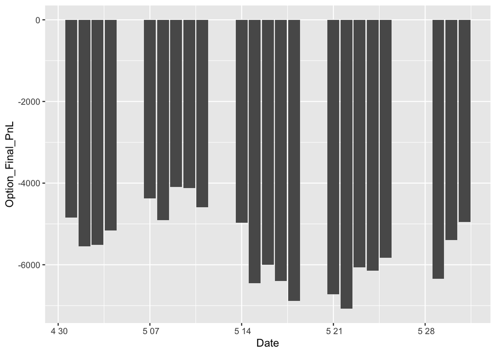

```r
res1 <-dplyr::filter(df1, month == 5)
ggplot(res1,aes(Date,Option_Final_PnL))+geom_col()
```

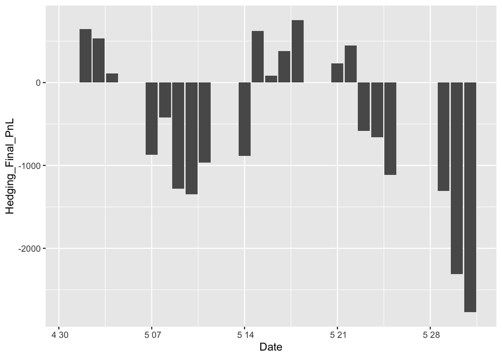

```r
ggplot(res1,aes(Date,Hedging_Final_PnL))+geom_col()
```

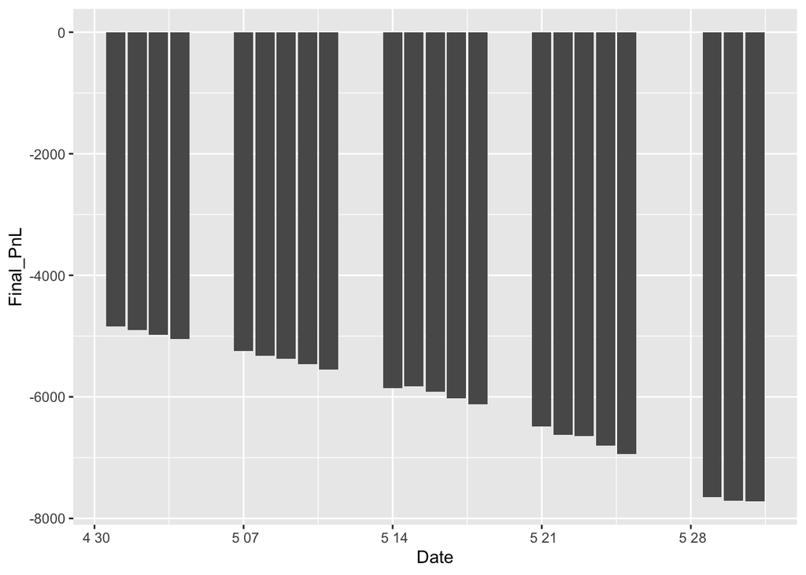

```r
ggplot(res1,aes(Date,Final_PnL))+geom_col()
```

### 2.1.2 Backtest

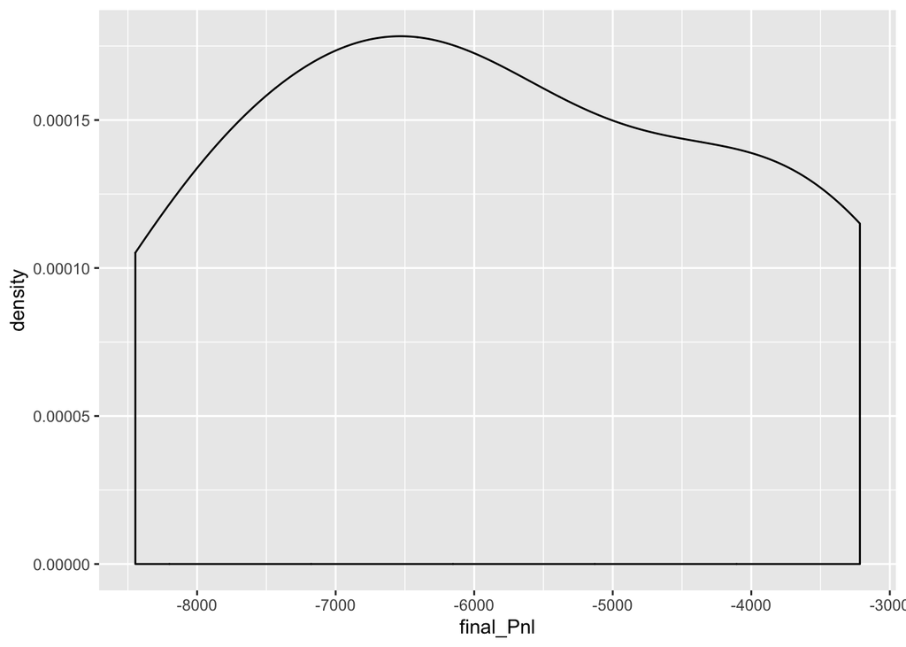

```r
ggplot(backtest,aes(final_Pnl))+geom_density()
```

## 2.2 Distribution of Max Drawdown

### 2.2.1 One Trade

For one trade, the max drawdown of Delta Hedge Strategy is controled under $1500.

It increases at a decreasing rate as time gets close to maturity.

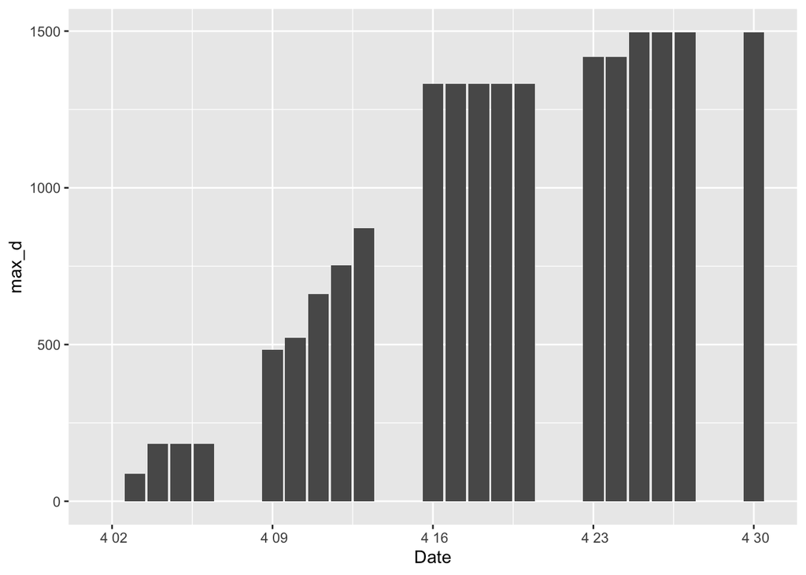

```r
res2 <-dplyr::filter(df1, month == 4)
ggplot(res2,aes(Date,max_d))+geom_col()
```

### 2.2.2 Backtest

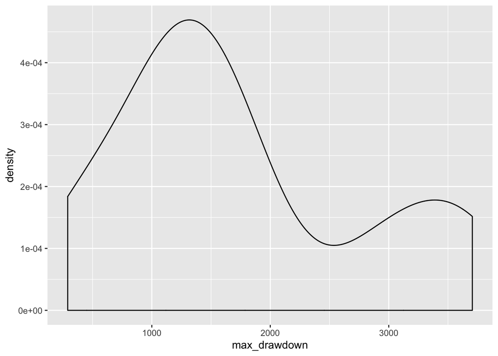

```r
ggplot(backtest,aes(max_drawdown))+geom_density()
```

## 2.3 Final Pnl vs Time to maturity

As time to maturity extends, final profit on **Option** side *decreases* while that on **Hedge** side *increases*.

As whole, final loss of delta hedge strategy increases stably as time to maturity reduces and converges to a certain number.

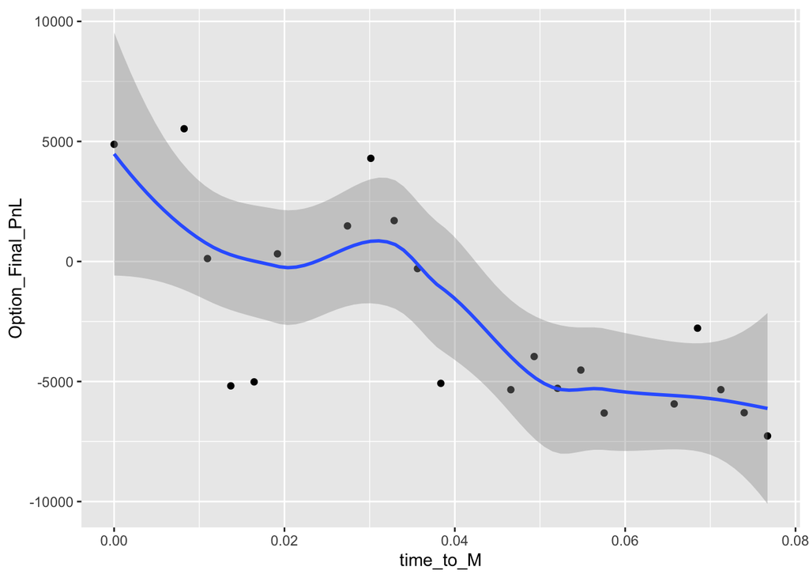

```r
res3 <-dplyr::filter(df1, month == 4)
ggplot(res3, aes(time_to_M,Option_Final_PnL))+geom_point()+geom_smooth()
```

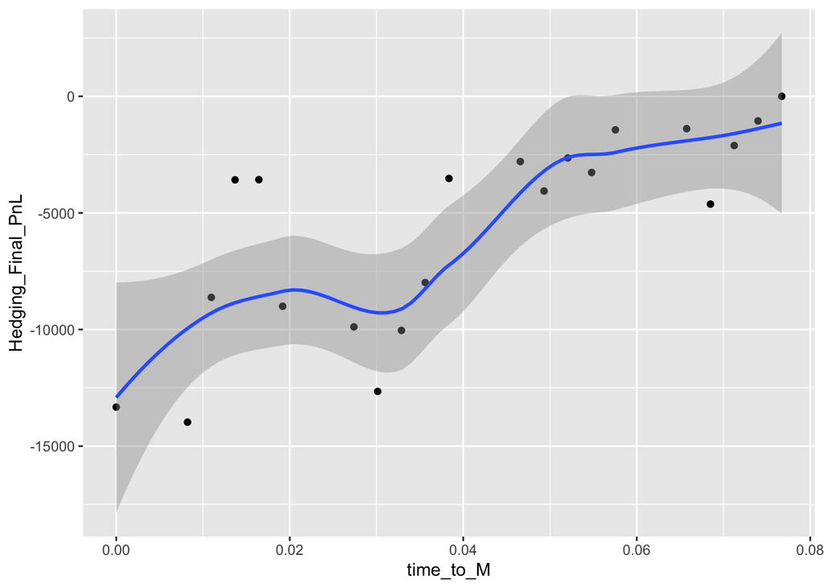

```r
ggplot(res3, aes(time_to_M,Hedging_Final_PnL))+geom_point()+geom_smooth()
```

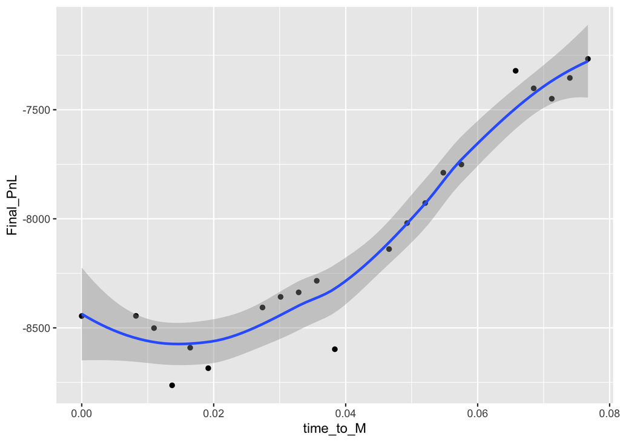

```r
ggplot(res3, aes(time_to_M,Final_PnL))+geom_point()+geom_smooth()
```

## 2.4 Daily Pnl vs Stock Price

Generally, the higher Stock Close Price is, the higher Daily Profit on Option side is while there is no obvious relationship between stock close price and Daily Profit and loss on Hedge side.

As a whole, however, daily profit and loss of delta hedge strategy keeps almost the **same**, which means the strategy can control loss in a reasonable range effectively.

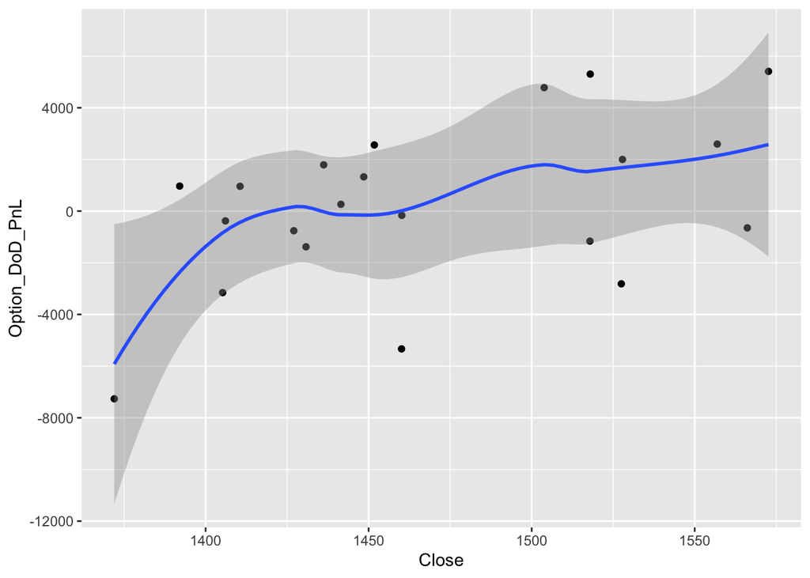

```r
res4 <-dplyr::filter(df1, month == 4)
ggplot(res4, aes(Close,Option_DoD_PnL))+geom_point()+geom_smooth()
```

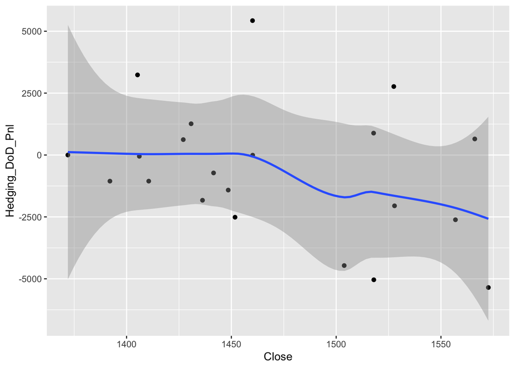

```r
ggplot(res4, aes(Close,Hedging_DoD_Pnl))+geom_point()+geom_smooth()
```

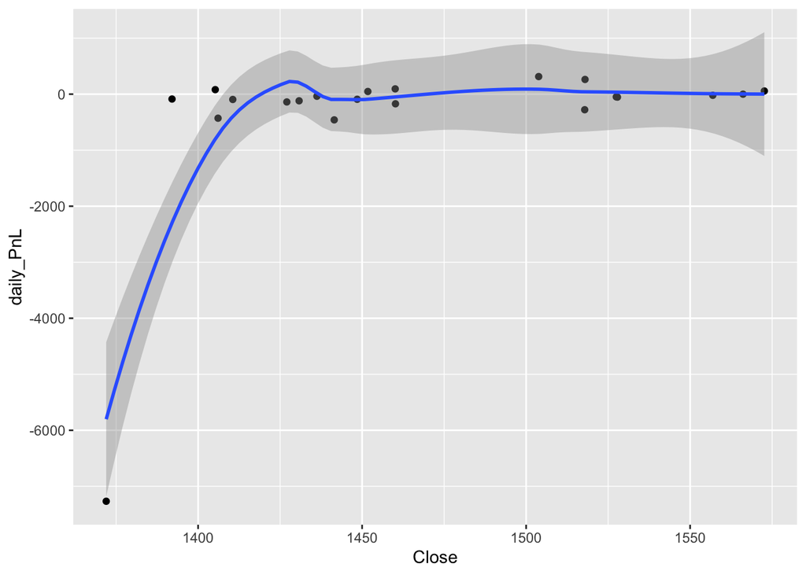

```r
ggplot(res4, aes(Close,daily_PnL))+geom_point()+geom_smooth()
```

## 2.5 Sharpe ratio vs Maturity date

There is no direct evidence which indicates a certain relationship between strategy’s Sharpe Ratio and time to maturity.

But all sharpe ratios are **positive** with an average of 0.3326959, which indicates the Effectiveness of delta hedge strategy.

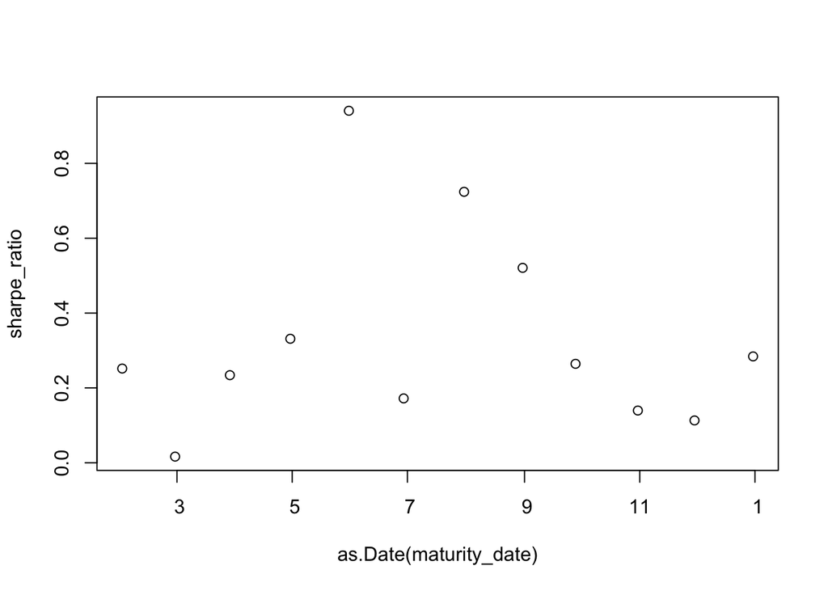

```r
plot(as.Date(maturity_date), sharpe_ratio)
```

# 2.6 Sharpe ratio vs difference between implied volatility and realized volatility

Generally speaking, ignoring outliers, sharpe ratio is a **linear** function of the square of difference between implied volatility and realized volatility.

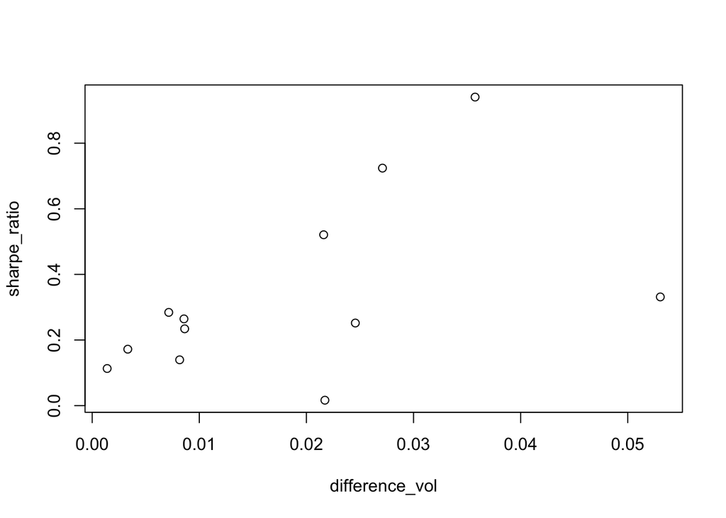

```r
difference_vol <- (implied_vol - realized_vol)**2
plot(difference_vol,sharpe_ratio)
```